# Simulation: eJAB vs AIC vs BIC for Model Selection

2025-02-18

## Goal

Compare **eJAB**, **AIC**, and **BIC** in a model-selection simulation across two scenarios: (A) selecting the correct model when the true model has two predictors, and (B) avoiding overfitting when extra noise predictors are available.

## eJAB function (from RPP)

```r
ejab01 <- function(p, n, q) {
  stopifnot(all(p > 0 & p < 1), all(n > 1), all(q >= 1))
  chi_quant <- qchisq(1 - p, df = q)
  sqrt(n) * exp(-0.5 * (n^(1/q) - 1) / n^(1/q) * chi_quant)
}
```

**Interpretation refresher**: eJAB is a Bayes-factor-like quantity measuring evidence *for the null*.

- **Small eJAB** (< 1) = strong evidence the alternative (larger model) is real.
- **Large eJAB** (> 1) = the null / simpler model is favored.

In the RPP pipeline, `ejab > C*` flags suspected Type I errors — studies where the p-value looks significant but the Bayes factor actually favors the null.

## Helpers

```r
clamp_p <- function(p) pmax(pmin(p, 1 - 1e-15), 1e-15)

generate_data <- function(n, betas, sigma = 1, n_noise = 0) {
  k <- length(betas) - 1
  X <- matrix(rnorm(n * (k + n_noise)), n, k + n_noise)
  colnames(X) <- paste0("x", seq_len(k + n_noise))
  y <- X[, seq_len(k), drop = FALSE] %*% betas[-1] + betas[1] + rnorm(n, 0, sigma)
  data.frame(y = as.numeric(y), X)
}
```

## Scenario A — True model with 2 predictors

**True model**: $y = 0.3 x_1 + 0.3 x_2 + \varepsilon$. Candidates: null, $x_1$, $x_2$, $x_1 + x_2$.

```r
fit_A <- function(d) {
  list(
    null = lm(y ~ 1,      data = d),
    M1   = lm(y ~ x1,     data = d),
    M2   = lm(y ~ x2,     data = d),
    M12  = lm(y ~ x1+x2,  data = d)
  )
}

select_aic <- function(fits) which.min(sapply(fits, AIC))
select_bic <- function(fits) which.min(sapply(fits, BIC))

# eJAB: compare each non-null model to null; select the one with the smallest
# eJAB (strongest evidence against null).  If all eJAB >= 1, select null.
select_ejab <- function(fits, n) {
  null_fit <- fits[["null"]]
  non_null <- fits[names(fits) != "null"]
  qs <- sapply(non_null, function(f) length(coef(f)) - length(coef(null_fit)))

  pvals <- sapply(non_null, function(f) {
    clamp_p(anova(null_fit, f)$`Pr(>F)`[2])
  })

  ejabs <- mapply(ejab01, p = pvals, n = n, q = qs)
  if (all(ejabs >= 1)) return(1L)
  1L + which.min(ejabs)
}

model_names_A <- c("null", "M1", "M2", "M12")
true_idx_A    <- 4L
```

```r
n_sims  <- 500
n_vec   <- c(25, 50, 100, 200)
res_A   <- list()

for (nn in n_vec) {
  counts <- matrix(0L, nrow = 4, ncol = 3,
                   dimnames = list(model_names_A, c("AIC", "BIC", "eJAB")))
  for (i in seq_len(n_sims)) {
    d    <- generate_data(nn, betas = c(0, 0.3, 0.3))
    fits <- fit_A(d)
    counts[select_aic(fits),         "AIC"]  <- counts[select_aic(fits),  "AIC"]  + 1L
    counts[select_bic(fits),         "BIC"]  <- counts[select_bic(fits),  "BIC"]  + 1L
    counts[select_ejab(fits, nn),    "eJAB"] <- counts[select_ejab(fits, nn), "eJAB"] + 1L
  }
  res_A[[as.character(nn)]] <- counts
}
```

### Correct-selection rate (true model = M12)

```r
tab_A <- do.call(rbind, lapply(names(res_A), function(nn) {
  m <- res_A[[nn]]
  data.frame(
    n    = as.integer(nn),
    AIC  = sprintf("%.1f%%", 100 * m["M12","AIC"]  / n_sims),
    BIC  = sprintf("%.1f%%", 100 * m["M12","BIC"]  / n_sims),
    eJAB = sprintf("%.1f%%", 100 * m["M12","eJAB"] / n_sims)
  )
}))
knitr::kable(tab_A, align = "r",
             caption = "Scenario A — % selecting true model (M12) out of 500 sims")
```

Scenario A — % selecting true model (M12) out of 500 sims

| n | AIC | BIC | eJAB |
| --- | --- | --- | --- |
| 25 | 31.8% | 16.2% | 35.2% |
| 50 | 58.0% | 30.8% | 66.2% |
| 100 | 86.6% | 61.0% | 92.6% |
| 200 | 99.2% | 94.0% | 99.8% |

### Full choice distributions

```r
for (nn in names(res_A)) {
  cat("\n### n =", nn, "\n")
  print(res_A[[nn]])
}
```

```
##
## ### n = 25
##      AIC BIC eJAB
## null 120 212  204
## M1   115 106   63
## M2   106 101   57
## M12  159  81  176
##
## ### n = 50
##      AIC BIC eJAB
## null  33 105   77
## M1    94 124   49
## M2    83 117   43
## M12  290 154  331
##
## ### n = 100
##      AIC BIC eJAB
## null   2  29   16
## M1    28  72    9
## M2    37  94   12
## M12  433 305  463
##
## ### n = 200
##      AIC BIC eJAB
## null   0   0    0
## M1     3  11    1
## M2     1  19    0
## M12  496 470  499
```

## Scenario B — Overfitting test (true model = null)

**True model**: $y = \varepsilon$ (no signal). Five candidate predictors are all noise. This tests whether each criterion correctly favors the null.

```r
fit_B <- function(d) {
  list(
    null = lm(y ~ 1, data = d),
    M1   = lm(y ~ x1, data = d),
    M2   = lm(y ~ x1+x2, data = d),
    M3   = lm(y ~ x1+x2+x3, data = d),
    M4   = lm(y ~ x1+x2+x3+x4, data = d),
    M5   = lm(y ~ x1+x2+x3+x4+x5, data = d)
  )
}

select_ejab_B <- function(fits, n) {
  null_fit <- fits[["null"]]
  non_null <- fits[names(fits) != "null"]
  qs <- sapply(non_null, function(f) length(coef(f)) - length(coef(null_fit)))
  pvals <- sapply(non_null, function(f) clamp_p(anova(null_fit, f)$`Pr(>F)`[2]))
  ejabs <- mapply(ejab01, p = pvals, n = n, q = qs)
  if (all(ejabs >= 1)) return(1L)
  1L + which.min(ejabs)
}

model_names_B <- c("null", paste0("M", 1:5))

res_B <- list()
for (nn in n_vec) {
  aic_c <- bic_c <- ejab_c <- setNames(integer(6), model_names_B)
  for (i in seq_len(n_sims)) {
    d    <- generate_data(nn, betas = c(0, rep(0, 5)), n_noise = 0)
    fits <- fit_B(d)
    a <- select_aic(fits);           aic_c[a]  <- aic_c[a]  + 1L
    b <- select_bic(fits);           bic_c[b]  <- bic_c[b]  + 1L
    e <- select_ejab_B(fits, nn);    ejab_c[e] <- ejab_c[e] + 1L
  }
  res_B[[as.character(nn)]] <- list(AIC = aic_c, BIC = bic_c, eJAB = ejab_c)
}
```

### Null-selection rate (true model = null, no signal)

```r
tab_B <- do.call(rbind, lapply(names(res_B), function(nn) {
  r <- res_B[[nn]]
  data.frame(
    n     = as.integer(nn),
    AIC   = sprintf("%.1f%%", 100 * r$AIC["null"] / n_sims),
    BIC   = sprintf("%.1f%%", 100 * r$BIC["null"] / n_sims),
    eJAB  = sprintf("%.1f%%", 100 * r$eJAB["null"] / n_sims)
  )
}))
knitr::kable(tab_B, align = "r",
             caption = "Scenario B — % correctly selecting null (no signal) out of 500 sims")
```

Scenario B — % correctly selecting null (no signal) out of 500 sims

| n | AIC | BIC | eJAB |
| --- | --- | --- | --- |
| 25 | 62.8% | 83.8% | 65.2% |
| 50 | 71.6% | 95.0% | 72.4% |
| 100 | 70.2% | 96.6% | 78.4% |
| 200 | 73.4% | 96.8% | 82.4% |

### Full choice distributions

```r
for (nn in names(res_B)) {
  r <- res_B[[nn]]
  cat("\n### n =", nn, "\n")
  cat("AIC:  ", paste(model_names_B, r$AIC,  sep="=", collapse=", "), "\n")
  cat("BIC:  ", paste(model_names_B, r$BIC,  sep="=", collapse=", "), "\n")
  cat("eJAB: ", paste(model_names_B, r$eJAB, sep="=", collapse=", "), "\n")
}
```

```
##
## ### n = 25
## AIC:   null=314, M1=64, M2=37, M3=32, M4=27, M5=26
## BIC:   null=419, M1=42, M2=16, M3=9, M4=8, M5=6
## eJAB:  null=326, M1=14, M2=29, M3=39, M4=45, M5=47
##
## ### n = 50
## AIC:   null=358, M1=56, M2=31, M3=16, M4=21, M5=18
## BIC:   null=475, M1=17, M2=5, M3=2, M4=1, M5=0
## eJAB:  null=362, M1=6, M2=20, M3=21, M4=41, M5=50
##
## ### n = 100
## AIC:   null=351, M1=63, M2=30, M3=26, M4=16, M5=14
## BIC:   null=483, M1=11, M2=5, M3=1, M4=0, M5=0
## eJAB:  null=392, M1=1, M2=18, M3=26, M4=25, M5=38
##
## ### n = 200
## AIC:   null=367, M1=61, M2=33, M3=20, M4=6, M5=13
## BIC:   null=484, M1=13, M2=2, M3=1, M4=0, M5=0
## eJAB:  null=412, M1=3, M2=11, M3=19, M4=20, M5=35
```

## Summary

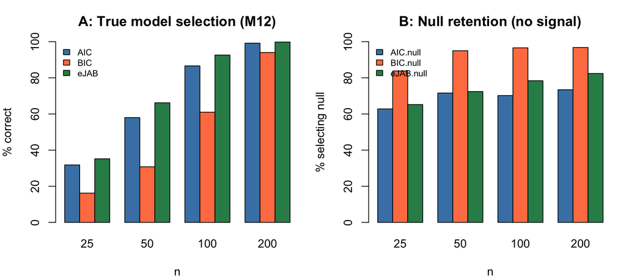

```r
par(mfrow = c(1, 2), mar = c(4, 4, 3, 1))

# Panel A — correct selection (true model has signal)
pct_A <- sapply(res_A, function(m) {
  c(AIC = m["M12","AIC"], BIC = m["M12","BIC"],
    eJAB = m["M12","eJAB"]) / n_sims * 100
})
colnames(pct_A) <- n_vec
barplot(pct_A, beside = TRUE, ylim = c(0, 100),
        col = c("steelblue","coral","seagreen"),
        xlab = "n", ylab = "% correct",
        main = "A: True model selection (M12)")
legend("topleft", rownames(pct_A), fill = c("steelblue","coral","seagreen"),
       cex = 0.75, bty = "n")

# Panel B — null retention (no signal)
pct_B <- sapply(res_B, function(r) {
  c(AIC = r$AIC["null"], BIC = r$BIC["null"], eJAB = r$eJAB["null"]) / n_sims * 100
})
colnames(pct_B) <- n_vec
barplot(pct_B, beside = TRUE, ylim = c(0, 100),
        col = c("steelblue","coral","seagreen"),
        xlab = "n", ylab = "% selecting null",
        main = "B: Null retention (no signal)")
legend("topleft", rownames(pct_B), fill = c("steelblue","coral","seagreen"),
       cex = 0.75, bty = "n")
```

Adjust `betas` and `sigma` to explore different signal-to-noise regimes.